# Insurance Claims Frequency and Severity

McQueen Insurances

# 1 Executive Summary

# 2 Data Preparation

## 2.1 Overview of the Dataset

The first step of the data exploration process is to load the insurance claims of our Belgian Motor Third Party Liability (MTPL) dataset. We will start ensuring the uniqueness of keys. Then, we’ll have a look at our target variables and the distribution of the exposure. Finally, we will have a quick look at the predictor variables we have before diving in the data transformation and exploration.

### 2.1.1 Uniqueness of Keys

Each row in the dataset represents a unique insurance policy (`ID`). We can verify the uniqueness of rows by checking if the number of unique `ID`s matches the total number of rows.

```r
setwd(paste0(
    "C:/Users/MathieuDemarets/Documents/UCL Certificat/",
    "CodeRepositories/LACTU2150/project"
))
load("../data/mtpl_be.rda")
data <- mtpl_be

n_unique_ids <- length(unique(data$ID))
n_rows <- nrow(data)
cat(sprintf(
    "Number of unique IDs: %d\nNumber of rows: %d\nAre they equal? %s",
    n_unique_ids, n_rows,
    ifelse(n_unique_ids == n_rows, "Yes", "No")
))
```

```
Number of unique IDs: 163231
Number of rows: 163231
Are they equal? Yes
```

### 2.1.2 Target Variables

For each policy, we have an exposure (`EXP`), which represents the fraction of the year that the policy was in force. The contract last a single year at most. Over that exposure time, we have the two target variables:

- **Frequency (`NCLAIMS`)**: The number of claims filed during the policy period.
- **Severity (`AVG`)**: The average cost per claim during the policy period.

The total claim cost is derived from the frequency and severity:

- **Total Claim Cost (`NCLAIMS * AVG = AMOUNT`)**: The total cost of claims during the policy period.[^1]

```r
qtable <- function(data, x, n_quant) {
    data_not_na <- data[!is.na(data[[x]]), ]
    if (sum(is.na(data[[x]])) > 0) warning(sprintf("Removing %d NA values from column %s", sum(is.na(data[[x]])), x))
    # Get the n_quantiles of the column x
    qx <- quantile(data_not_na[[x]], probs = seq(0, 1, by = 1 / n_quant))
    quantiles <- data.frame(Quantile = names(qx), Value = as.numeric(qx))
    quantiles$Value <- format(quantiles$Value, big.mark = ",", format = "f", digits = 2, scientific = FALSE)
    rownames(quantiles) <- quantiles$Quantile
    quantiles$Quantile <- NULL
    quantiles %>% t() %>% as.data.frame() %>% kable(
    caption = sprintf("Quantiles of %s", x),
    booktabs = FALSE
    ) %>% kableExtra::kable_styling(full_width = FALSE, position = "left")
}
```

```r
qtable(data, "NCLAIMS", 10)
```

Quantiles of NCLAIMS

|  | 0% | 10% | 20% | 30% | 40% | 50% | 60% | 70% | 80% | 90% | 100% |
| --- | --- | --- | --- | --- | --- | --- | --- | --- | --- | --- | --- |
| Value | 0 | 0 | 0 | 0 | 0 | 0 | 0 | 0 | 0 | 1 | 5 |

```r
p1 <- ggplot(data, aes(x = NCLAIMS)) +
    geom_bar() +
    labs(
        title = "NCLAIMS Distribution",
        x = "Number of Claims",
        y = sprintf("Count (All: %d)", nrow(data))
    ) +
    theme_minimal()

qtable(data, "AVG", 10)
```

Quantiles of AVG

|  | 0% | 10% | 20% | 30% | 40% | 50% | 60% | 70% | 80% | 90% | 100% |
| --- | --- | --- | --- | --- | --- | --- | --- | --- | --- | --- | --- |
| Value | 0.025 | 68.959 | 124.066 | 150.372 | 203.967 | 529.773 | 942.114 | 1,426.379 | 1,501.724 | 2,563.050 | 1,989,567.897 |

```r
filtered_AVG <- data %>% filter(!is.na(AVG))

p2 <- ggplot(filtered_AVG, aes(x = log(AVG))) +
    geom_histogram(bins = 30) +
    labs(
        title = "AVG Distribution",
        x = "Log of Average Claim Cost",
        y = sprintf("Count (All: %d)", nrow(filtered_AVG))
    ) +
    theme_minimal()

qtable(data, "AMOUNT", 10)
```

Quantiles of AMOUNT

|  | 0% | 10% | 20% | 30% | 40% | 50% | 60% | 70% | 80% | 90% | 100% |
| --- | --- | --- | --- | --- | --- | --- | --- | --- | --- | --- | --- |
| Value | 0 | 0 | 0 | 0 | 0 | 0 | 0 | 0 | 0 | 71 | 1,989,568 |

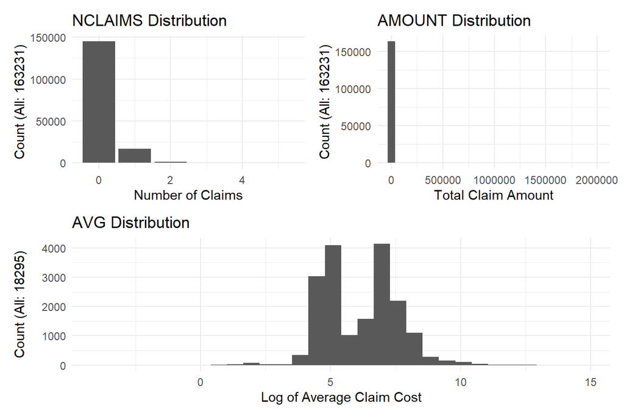

```r
filtered_AMOUNT <- data %>% filter(!is.na(AMOUNT))
p3 <- ggplot(filtered_AMOUNT, aes(x = AMOUNT)) +
    geom_histogram(bins = 30) +
    labs(
        title = "AMOUNT Distribution",
        x = "Total Claim Amount",
        y = sprintf("Count (All: %d)", nrow(filtered_AMOUNT))
    ) +
    theme_minimal()


(p1 | p3 )/ p2
```

For both the frequency and severity of claims, we observe a large distribution mass around zero. This is quite typical in insurance data, where many policies have no claims or very low average claim costs. We also note that 144936 policies have missing average claim costs. This is simply because no claims were reported for these policies (144936 policies with no claims). The claim amount is by nature zero in this case, and the average ($\frac{AMOUNT}{NCLAIMS}$) is undefined and not informative. When we will tackle the modeling of claim severity, we will therefore focus only on policies with at least one claim. To handle unbalanced data in the frequency modelling, various techniques are available such as:

- Synthetic oversampling techniques (e.g., SMOTE) create synthetic samples for the minority class to balance the dataset.
- Hurdle models can be employed to separately model the zero and non-zero counts, effectively handling the excess zeros in the data and focusing on the non-zero records in the second part of the model.

These are outside the scope of this analysis, it is nevertheless important to note that this unbalance will limit the frequency modelling performance and that these techniques could be explored in the future.

We can also note that the distribution of average claim is more interesting to look at. Indeed, we exclude policies with no claims, as their average claim is undefined. Then, we can take the logarithm of the average claim to better visualize the scale of cost instead of the absolute values. The quantiles indeed show us a very skewed distribution, with most average claims being relatively low but a few policies having very high average claims. We can see two peaks in the log-transformed average claim distribution which indicates the presence of different kind of claims:

- First peak corresponds to small dents and repairs: the log around 5 represents claims of approximately 148 euros
- Second peak corresponds to more significant repairs: the log around 7.5 represents claims of approximately 1808 euros
- Right tail corresponds to way bigger damages: the log around 10 represents claims of approximately 22026 euros

Even if they are not so frequent, the larger claims in the right tail can have a significant impact on the company profitability. A future report could use `Extreme Value Theory` to better model and understand these rare but impactful claims.

```r
qtable(data, "EXP", 10)
```

Quantiles of EXP

|  | 0% | 10% | 20% | 30% | 40% | 50% | 60% | 70% | 80% | 90% | 100% |
| --- | --- | --- | --- | --- | --- | --- | --- | --- | --- | --- | --- |
| Value | 0.0027 | 0.4630 | 0.8822 | 1.0000 | 1.0000 | 1.0000 | 1.0000 | 1.0000 | 1.0000 | 1.0000 | 1.0000 |

Regarding the exposure, we see that a large majority of the policies have an exposure close to 1, indicating that most policies are active for nearly the entire year. About 0.23 of the policies have an exposure less than 1. This does not suggest that an analysis per exposure level is necessary.

Exposure should still be considered to correctly estimate the claim frequency as counting full exposure would underestimate the risk. The correct way to compute the mean claim frequency is
$$\frac{\sum{NCLAIMS}}{\sum{EXP}}, \text{ where }
EXP \in [0, 1]$$
will therefore be hugher than the naive mean
$$\frac{\sum{NCLAIMS}}{nrow(data) =
\sum{1}}$$

```r
mean_claim_frequency <- sum(data$NCLAIMS) / sum(data$EXP)
se_mean <- sqrt(mean_claim_frequency / sum(data$EXP))
ic_99 <- mean_claim_frequency + c(-1, 1) * 2.576 * se_mean
wrong_mean <- mean(data$NCLAIMS)
cat(sprintf(
    "Correct mean claim frequency: %.3f%% (99%% CI: [%.3f%%, %.3f%%])\nNaive mean: %.3f%%",
    mean_claim_frequency * 100,
    ic_99[1] * 100,
    ic_99[2] * 100,
    wrong_mean * 100
))
```

```
Correct mean claim frequency: 13.934% (99% CI: [13.681%, 14.186%])
Naive mean: 12.397%
```

This confirms that the naive mean of `NCLAIMS` falls short of the 99% confidence interval for the correct mean claim frequency. It is therefore crucial to account for the exposure through the offset[^2] in the frequency modelling.

### 2.1.3 All Variables

```r
col_types <- sapply(data, class)

knitr::kable(
    data.frame(
        Type = col_types,
        Center = sapply(data, function(x) {
            if (is.numeric(x)) {
                mean(x, na.rm = TRUE) %>% round(4)
            } else {
                counts <- sort(table(x), decreasing = TRUE)
                names(counts)[1]
            }
        }),
        Missing = sapply(data, function(x) sum(is.na(x)))
    ),
    caption = "Overview of variable in the insurance claims dataset",
    booktabs = TRUE
) %>% kableExtra::kable_styling(full_width = TRUE, position = "left")
```

Overview of variable in the insurance claims dataset

|  | Type | Center | Missing |
| --- | --- | --- | --- |
| ID | integer | 81616 | 0 |
| NCLAIMS | integer | 0.124 | 0 |
| AMOUNT | numeric | 200.8407 | 0 |
| AVG | numeric | 1625.589 | 144936 |
| EXP | numeric | 0.8897 | 0 |
| COVERAGE | character | TPL | 0 |
| FUEL | character | gasoline | 0 |
| USE | character | private | 0 |
| FLEET | character | N | 0 |
| SEX | character | male | 0 |
| AGEPH | integer | 47 | 0 |
| BM | integer | 3.2687 | 0 |
| AGEC | integer | 7.375 | 0 |
| POWER | integer | 56.004 | 0 |
| PC | integer | 5270.7393 | 0 |
| TOWN | character | CHARLERO | 0 |
| LONG | numeric | 4.4072 | 0 |
| LAT | numeric | 50.7584 | 0 |

We can also notice that some columns have been asigned the wrong type:

- **COVERAGE, FUEL, USE, FLEET, SEX, and TOWN** should be set as unordered factor variables instead of character variables.
- **PC** should be converted from integer to an unordered factor variable.

This leads us to our next section on data transformation.

## 2.2 Data Transformation

### 2.2.1 Categorical Variables

As concluded at the end of the last section, we need to transform some character variables to factor variables. We will also make sure that the most frequent level (Center in the previous overview) is set as the reference level for unordered factor variables.

```r
for (col in c("COVERAGE", "FUEL", "USE", "FLEET", "SEX", "TOWN", "PC")) {
    data[[col]] <- as.factor(data[[col]]) %>% fct_infreq()
}
```

We can then assert that the categorical variables (ordered or unordered) have the correct reference levels. Note that our function also checks for ordered factor variables, ensuring that the reference level is the lowest level in this case. This does not happen in our dataset. The variable `BM` could be considered as unordered as we know that a higher `BM` score indicates a more risky driver but we don’t know if the jumps between the levels are constant. We decided to treat it as numerical because the numeric variable will be binned with a weight of evidence (WoE) approach and it will yield more meaningful bins than simple singleton bins.

```r
assert_ref_level <- function(data, cols) {
    for (col in cols) {
        if (!is.factor(data[[col]])) stop(paste(col, "is not a factor variable"))
        if (is.ordered(data[[col]])) {
            if (as.numeric(levels(data[[col]]))[1] != min(as.numeric(as.character(data[[col]])), na.rm = TRUE)) {
            # Pay attention to turn labels as numeric and not the factor internal codes which are just integers starting from 1
                stop(paste("Reference level for", col, "is not the lowest level"))
            }
        } else {
            if (
                levels(data[[col]])[1] !=
                    fct_count(data[[col]], sort = TRUE)$f[1]
            ) {
                stop(
                    paste(
                        "Reference level for", col,
                        "is not the most frequent level"
                    )
                )
            }
    }
    }
    cat("Reference levels for", paste(cols, collapse = ", "), "are correctly set\n")
}
assert_ref_level(data,  c("COVERAGE", "FUEL", "USE", "FLEET", "SEX", "TOWN", "PC"))
```

```
Reference levels for COVERAGE, FUEL, USE, FLEET, SEX, TOWN, PC are correctly set
```

### 2.2.2 Numerical Variables Binning

For the initial `GLM` modeling, we will need to discretize the continuous numerical variables into bins. We will use the same binning strategy for discrete variables to reduce the amount of bins and simplify the model interpretation. Defining optimal binning for a numerical variable is a complex and important step. There are a set of naive approaches that can be used:

- Singleton bins: Each unique value of the numerical variable is treated as a separate bin.
- Equal-width bins: The range of the variable is divided into intervals of equal width.
- Equal-frequency bins: Quantiles of the variable are used to create bins with approximately the same number of observations.

For this project, we will try to implement a more complex approach based on weight of evidence (WoE) to automatically determine a suitable binning for numerical variables. The idea of WoE binning is to group values based on how strongly they are associated with the target variable (binary outcome encoded as 0 if claim = 0 and 1 if claim >= 1):

$$\text{WoE} = \ln \frac{\text{proportion
of Good Outcomes in the bin}}{\text{proportion of Bad Outcomes in the
bin}}$$

Based on the WoE values, we can also compute the information value (IV) for each variable, which measures the predictive power of the variable with respect to the target. The IV is calculated as:

$$\text{IV} = \sum (\text{proportion of
Good Outcomes in the bin} - \text{proportion of Bad Outcomes in the
bin}) \times \text{WoE}$$

The IV value helps to assess the predictive power of a variable for the binning we have chosen. The idea of the algorithm will be to:

- Start with an adapted quantile-based binning as a baseline with a maximum number of bins specified.
- Iteratively merge bins based on bins with minimal information value (IV) contribution and assess total IV after each merge.
- Find the elbow point where the marginal contribution of one additional bin to the total IV decreases significantly.

We will take that elbow point and its associated bins boundaries for the final binning of the variable. We will detail each step of the algorithm with an example using the `AGEPH` variable.

#### 2.2.2.1 Baseline Quantile Binning

Our function `qbinning` is a simple algorithm that will start from the maximum number of bins specified by `max_bins` and iteratively reduce the number of bins until each bin contains at least one claim. This will ensure that the weight of evidence (WoE) can be calculated for each bin, as each bin will have at least one claim. We’ll then avoid having an undefined WoE.

```r
qbinning <- function(data, x, y, max_bins = 10) {
    "Quantile-based binning for numerical variable x with respect to binary target y"
    if (sum(data[[y]] >= 1) == 0) stop("No claims in the dataset")
    if (sum(data[[y]] == 0) == 0) stop("No non-claims in the dataset")
    if (!is.numeric(data[[x]])) stop("Variable x must be numeric")
    raw_data <- data
    temp_n <- max_bins
    temp_binning <- NULL
    baseline_bins <- NULL
    while (temp_n > 1) {
        temp_binning <- unique(
            quantile(raw_data[[x]], probs = seq(0, 1, length.out = temp_n + 1), na.rm = TRUE)
        )
        # check if there is at least one claim in each bin
        bin_claims <- tapply(
            raw_data[[y]],
            cut(raw_data[[x]], temp_binning, include.lowest = TRUE),
            function(z) sum(z >= 1))
        if (all(bin_claims > 0)) {
            baseline_bins <- temp_binning
            break
        }
        temp_n <- temp_n - 1
    }
    baseline_bins
}
```

```r
bins_ageph <- qbinning(data, x = "AGEPH", y = "NCLAIMS", max_bins = 30)
counts <- tapply(
    data[["NCLAIMS"]],
    cut(data[["AGEPH"]], bins_ageph, include.lowest = TRUE),
    function(z) sum(z >= 1)
)

df_bins <- data.frame(
    bin = factor(names(counts), levels = names(counts)),
    count = as.numeric(counts)
)

p <- ggplot(df_bins, aes(x = bin, y = count)) +
ggtitle("Baseline Quantile Binning (AGEPH)") +
geom_col(fill = "steelblue") +
labs(x = "AGEPH baseline quantile bin", y = "Policies with at least one claim") +
theme_minimal() +
theme(axis.text.x = element_text(angle = 60, hjust = 1))
ggplotly(p)
```

[interactive chart not shown]

Starting with 30 quantile bins, we apply our tweaked function `qbinning` to the `AGEPH` variable and find these 30 bins with somepolicies having at least one claim.

#### 2.2.2.2 Weight of Evidence (WoE) and Information Value (IV) Calculation

Based on the formula presented above, the weight of evidence (WoE) for each bin can be calculated as the natural logarithm of:

- $\text{proportion of Good Outcomes in the bin} = \frac{\text{Number of Good Outcomes in the bin}}{\text{Total Number of Good Outcomes}}$
- $\text{proportion of Bad Outcomes in the bin} = \frac{\text{Number of Bad Outcomes in the bin}}{\text{Total Number of Bad Outcomes}}$

If the bin has as much good (no claim) as bad (at least one claim) outcomes, the WoE will be zero as there is very little predictive power in that bin. If the bin has more good outcomes than bad outcomes, the WoE will be positive, indicating that the bin is associated with a lower risk. Finally, if the bin has more bad outcomes than good outcomes, the WoE will be negative, indicating that the bin is associated with a higher risk.

The Information Value (IV) is a measure based on the Weight of Evidence (WoE) that quantifies the predictive power of a feature in distinguishing between good and bad outcomes. It is calculated as:

$$\text{IV} = \sum_{\text{bins}}
(\text{proportion of Good Outcomes in the bin} - \text{proportion of Bad
Outcomes in the bin}) \times \text{WoE of the bin}$$

```r
woe_calc <- function(data, x, y, bins) {
    "Calculate Weight of Evidence (WoE) for each bin"
    woe_df <- data
    binned_woe <- tapply(
        woe_df[[y]],
        cut(woe_df[[x]], bins, include.lowest = TRUE),
        function(z) c(good = sum(z == 0), bad = sum(z >= 1))
    )
    binned_woe_df <- data.frame(
        bin = factor(names(binned_woe), levels = names(binned_woe)),
        good = sapply(binned_woe, function(x) x["good"]),
        bad = sapply(binned_woe, function(x) x["bad"])
    )
    rownames(binned_woe_df) <- NULL
    binned_woe_df$prop_good <- binned_woe_df$good / sum(binned_woe_df$good)
    binned_woe_df$prop_bad <- binned_woe_df$bad / sum(binned_woe_df$bad)
    binned_woe_df$woe <- log(binned_woe_df$prop_good / binned_woe_df$prop_bad)
    binned_woe_df$iv <- iv <- (binned_woe_df$prop_good - binned_woe_df$prop_bad) * binned_woe_df$woe
    return(binned_woe_df)
}

plot_woe_iv <- function(woe_df, interactive = TRUE) {
    max_woe <- max(abs(woe_df$woe))
    max_iv <- max(abs(woe_df$iv))
    # Avoid dividing by zero when all values are zero
    scale_factor <- if (max_woe > 0 && max_iv > 0) {
        max_woe / max_iv
    } else {
        1
    }
    p <- ggplot(woe_df, aes(x = bin)) +
        geom_col(
            aes(y = woe, fill = woe > 0),
            width = 0.8,
            show.legend = FALSE
        ) +
        scale_fill_manual(
            values = c("FALSE" = "firebrick", "TRUE" = "forestgreen")
        ) +
        geom_line(
            aes(y = iv * scale_factor, group = 1),
            color = "blue"
        ) +
        geom_point(
            aes(y = iv * scale_factor),
            color = "blue",
        ) +
        scale_y_continuous(
            name = "WoE and Scale-adjusted IV"
        ) +
        labs(x = "Bins") +
        theme_minimal() +
        theme(
            axis.text.x = element_text(angle = 60, hjust = 1),
        ) +
        ggtitle(
            paste0("WoE and IV (bins=", length(woe_df$bin), ")")
        )
    if (interactive) {
        ggplotly(p)
    } else {
        return(p)
    }
}
```

```r
woe_ex <- woe_calc(data, x = "AGEPH", y = "NCLAIMS", bins = bins_ageph)
plot_woe_iv(woe_ex)
```

[interactive chart not shown]

The example for `AGEPH` already shows very interesting patterns for our baseline binning:

- The WoE values go from negative to positive, indicating that the younger age groups have a higher likelihood of bad outcomes (at least one claim) compared to the older age groups.
- The IV line shows a very high contribution from the young and older age groups, indicating that these bins are the most predictive for the likelihood of claims.

Let’s confirm the relationship between age and number of claims by examining correlation between `AGEPH` and `NCLAIMS` and visualizing it.

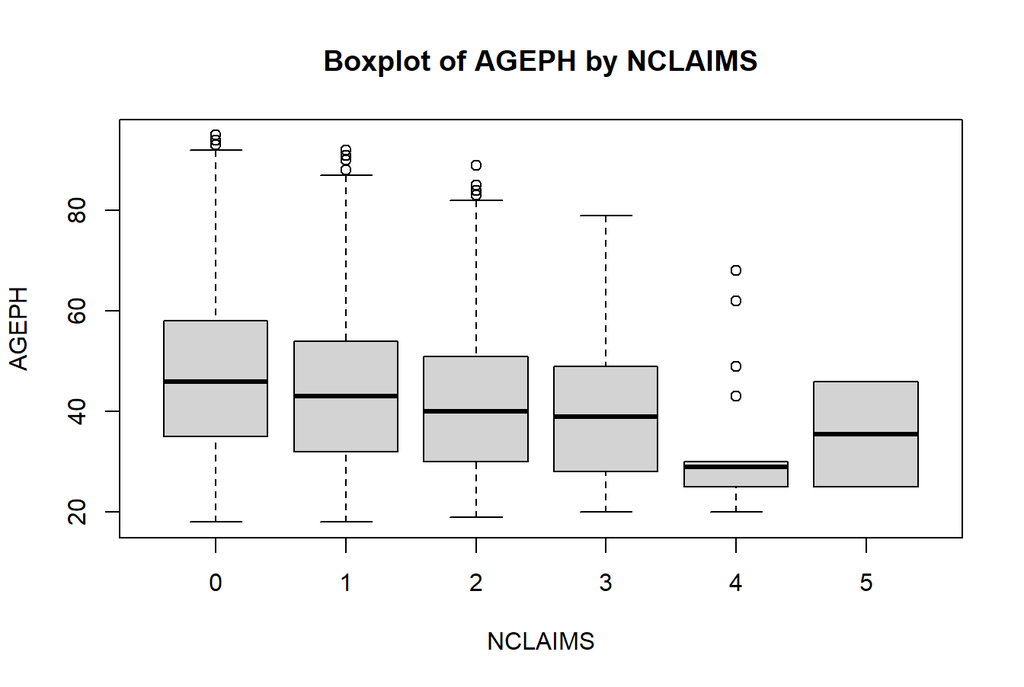

```r
# boxplot of age for each number of claims
boxplot(AGEPH ~ NCLAIMS, data = data, xlab = "NCLAIMS", ylab = "AGEPH", main = "Boxplot of AGEPH by NCLAIMS")
```

```r
# claim frequency in our example bins, group by bin
age_quantiles <- cut(data$AGEPH, breaks = bins_ageph, include.lowest = TRUE)
gpd_data <- data %>%
    mutate(age_bin = age_quantiles) %>%
    group_by(age_bin) %>%
    summarise(
        sum_exp = sum(EXP),
        sum_claims = sum(NCLAIMS),
        lambda = sum_claims / sum_exp,
        sd_lambda = sqrt(lambda / sum_exp),
        lambda_95_lower = lambda - 1.96 * sd_lambda,
        lambda_95_upper = lambda + 1.96 * sd_lambda,
        lambda_99_lower = lambda - 2.58 * sd_lambda,
        lambda_99_upper = lambda + 2.58 * sd_lambda
    )
# Plot the claim frequency (lambda) with filled error bars 95 and 99 percent confidence intervals
p2 <- ggplot(gpd_data, aes(x = age_bin, group = 1)) +
    geom_ribbon(
        aes(ymin = lambda_99_lower, ymax = lambda_99_upper),
        fill = "gray", alpha = 0.3, label = "99% CI"
    ) +
    geom_ribbon(
        aes(ymin = lambda_95_lower, ymax = lambda_95_upper),
        fill = "lightblue", alpha = 0.5, label = "95% CI"
    ) +
    geom_line(aes(y = lambda), color = "black") +
    geom_point(aes(y = lambda), color = "black") +
    theme_minimal() +
    scale_y_continuous(labels = scales::comma) +
    labs(
        x = "Age Bin",
        y = "Claim Frequency (Lambda)",
        title = "Claim Frequency by Age Bin"
    ) +
    theme(axis.text.x = element_text(angle = 45, hjust = 1))
ggplotly(p2)
```

[interactive chart not shown]

The boxplots show that the group of policyholders with lower amount of claims do tend to be older. It is even more striking when we look at the claim frequency by age bin with the confidence intervals[^3].

#### 2.2.2.3 Iterative Merging Based on Information Value (IV)

Remember that the Information Value (IV) is a measure based on the Weight of Evidence (WoE) that quantifies the predictive power of a feature in distinguishing between good and bad outcomes. It is calculated as:

$$\text{IV} = \sum_{\text{bins}}
(\text{proportion of Good Outcomes in the bin} - \text{proportion of Bad
Outcomes in the bin}) \times \text{WoE of the bin}$$

We have an information value for each bin, which allows us to identify the adjacent bins that contribute the least to the overall predictive power and merge them iteratively. The goal is to recursively merge the bin with lowest IV contribution with its neighboring bin, and evaluate the resulting IV. Then we can find the elbow point where further merging would lead to a significant loss of predictive power.

```r
iv_elbow <- function(data, x, y, bins) {
    "Recursively merge the bin with the lowest IV contribution with its neighboring bin with minimum IV"

    temp_bins <- bins
    temp_n_bins <- length(bins) - 1
    temp_woe_df <- woe_calc(data, x, y, temp_bins)
    temp_iv <- temp_woe_df$iv
    temp_total_iv <- sum(temp_iv)

    iter_log <- data.frame(
        n_bins = temp_n_bins,
        iv = temp_total_iv,
        bins = paste(temp_bins, collapse = ","),
        diff = NA,
        diff_order = NA
    )

    while(temp_n_bins > 2) {
        bin_to_merge <- which.min(temp_iv)
        if (bin_to_merge == 1) {
            neighbor <- 2
        } else if (bin_to_merge == temp_n_bins) {
            neighbor <- temp_n_bins - 1
        } else {
            neighbor <- ifelse(temp_iv[bin_to_merge - 1] < temp_iv[bin_to_merge + 1], bin_to_merge - 1, bin_to_merge + 1)
        }
        to_merge <- sort(c(bin_to_merge, neighbor))
        temp_bins <- temp_bins[-to_merge[2]]
        temp_n_bins <- length(temp_bins) - 1
        temp_woe_df <- woe_calc(data, x, y, temp_bins)
        temp_iv <- temp_woe_df$iv
        temp_total_iv <- sum(temp_iv)

        iter_log <- rbind(iter_log, data.frame(
            n_bins = temp_n_bins,
            iv = temp_total_iv,
            bins = paste(temp_bins, collapse = ","),
            diff = NA,
            diff_order = NA
        ))
    }
    iter_log <- iter_log %>% arrange(n_bins)
    iter_log$diff <- c(NA, abs(diff(iter_log$iv)))
    iter_log$diff[is.na(iter_log$diff)] <- 0
    iter_log$diff_order <- rank(-iter_log$diff)
    return(iter_log)
}
plot_iv_elbow <- function(iv_elbow_result, interactive = TRUE) {
    first_max_diff <- filter(iv_elbow_result, diff_order == 1)
    p <- ggplot(iv_elbow_result, aes(x = n_bins, y = iv)) +
        geom_line() +
        geom_point() +
        labs(title = "Information Value Elbow Plot", x = "Number of Bins", y = "Information Value") +
        theme_minimal() +
        geom_vline(xintercept = first_max_diff$n_bins, linetype = "dashed", color = "red") +
        geom_hline(yintercept = first_max_diff$iv, linetype = "dashed", color = "red")
    if (interactive) {
        ggplotly(p)
    } else {
        return(p)
    }
}
```

```r
result <- iv_elbow(data, "AGEPH", "NCLAIMS", bins_ageph)
plot_iv_elbow(result, interactive = TRUE)
```

[interactive chart not shown]

Looking at the IV elbow plot and taking the number of bins corresponding to the first maximum difference in IV as the optimal choice, we can rebuild the bins with only three bins. Adding a single bin seems sensible as we capture more information with a single additional split. We could also consider 7 or 12 bins that mark other levels in the IV - Number of Bins relationship.

```r
rebuild_bins <- function(iv_elbow_result, n) {
    "Rebuild bins based on the IV elbow result for the specified number of bins"
    target_row <- iv_elbow_result %>% filter(n_bins == n)
    bins <- as.numeric(unlist(strsplit(target_row$bins, ",")))
    return(bins)
}
```

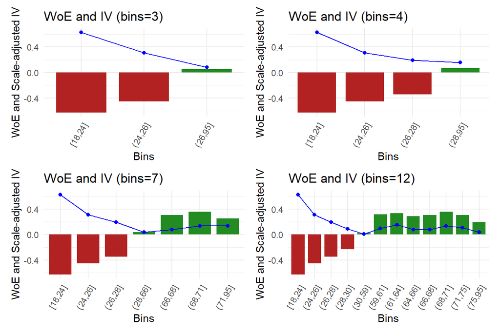

```r
plots <- list()
for (i in c(3, 4, 7, 12)) {
    temp_bins <- rebuild_bins(result, i)
    woe_temp <- woe_calc(data, x = "AGEPH", y = "NCLAIMS", bins = temp_bins)
    plots[[i]] <- plot_woe_iv(woe_temp, interactive = FALSE)
}
(plots[[3]] | plots[[4]] ) / (plots[[7]] | plots[[12]])
```

Based on the comparison above, the optimal amount of bins seems to be 7 because:

- We capture in fine granularity the effet of young ages with higher risk.
- We skip the middle of the age distribution which brings no additional information (28 to 66).
- We capture the effect of older ages with lower risk profiles with good granularity.
- We see that last effect fading slightly for the oldest ages (above 71)

The complex pattern we noticed in our initial 30 bins seems to be well captured with 7 bins only.

```r
# We add the ordered factor variable for the binned AGEPH
data$AGEPH_binned <- cut(
    data$AGEPH,
    breaks = rebuild_bins(result, 7), include.lowest = TRUE, ordered_result = TRUE)
# Check the distribution of the binned variable
summary(data$AGEPH_binned) %>%
    kable(
        caption = "Distribution of binned AGEPH",
        booktabs = TRUE
    )
```

Distribution of binned AGEPH

|  | x |
| --- | --- |
| [18,24] | 5585 |
| (24,26] | 5614 |
| (26,28] | 6324 |
| (28,66] | 125127 |
| (66,68] | 4364 |
| (68,71] | 5474 |
| (71,95] | 10743 |

#### 2.2.2.4 Bonus-Malus Binning (BM)

```r
baseline_bm <- qbinning(data, x = "BM", y = "NCLAIMS", max_bins = 30)
result_bm <- iv_elbow(data, "BM", "NCLAIMS", baseline_bm)
plot_iv_elbow(result_bm, interactive = TRUE)
```

[interactive chart not shown]

Based on the Elbow plot for the Bonus-Malus (`BM`), let’s try 3, 4, 5, and 11 bins.

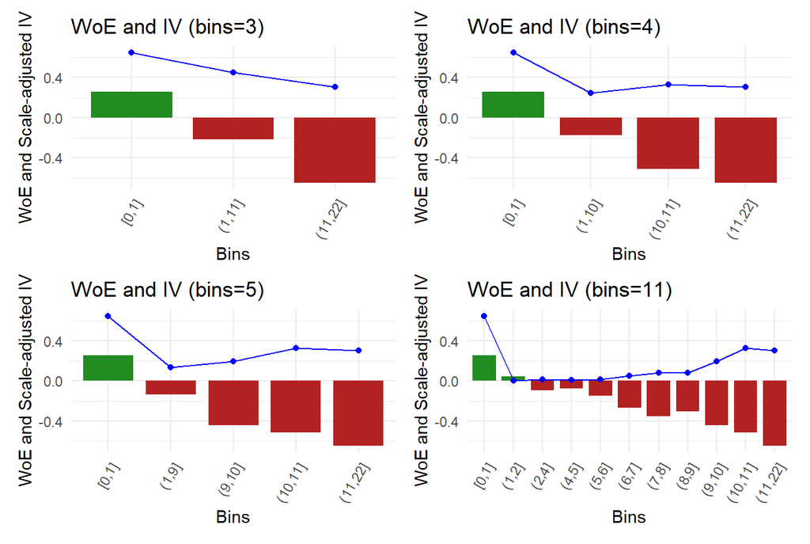

```r
plots_bm <- list()
for (i in c(3, 4, 5, 11)) {
    temp_bins_bm <- rebuild_bins(result_bm, i)
    woe_temp_bm <- woe_calc(data, x = "BM", y = "NCLAIMS", bins = temp_bins_bm)
    plots_bm[[i]] <- plot_woe_iv(woe_temp_bm, interactive = FALSE)
}
(plots_bm[[3]] | plots_bm[[4]] ) / (plots_bm[[5]] | plots_bm[[11]])
```

We see that most information is captured by the first bin indicating that those with a BM of 0 are significantly safer than the others. The three bins are sufficient to capture the separate the first and second risk groups that are the first and second half of the BM score. Adding bins just creates bins in between with low informational value.

```r
data$BM_binned <- cut(
    data$BM,
    breaks = rebuild_bins(result_bm, 3), include.lowest = TRUE, ordered_result = TRUE)
```

#### 2.2.2.5 Age of the Car Binning (AGEC)

```r
baseline_agec <- qbinning(data, x = "AGEC", y = "NCLAIMS", max_bins = 30)
result_agec <- iv_elbow(data, "AGEC", "NCLAIMS", baseline_agec)
plot_iv_elbow(result_agec, interactive = TRUE)
```

[interactive chart not shown]

For the age of the car (`AGEC`), we see a plateau after around 5 bins, let’s compare 3, 4, 5, and 16 (max) bins.

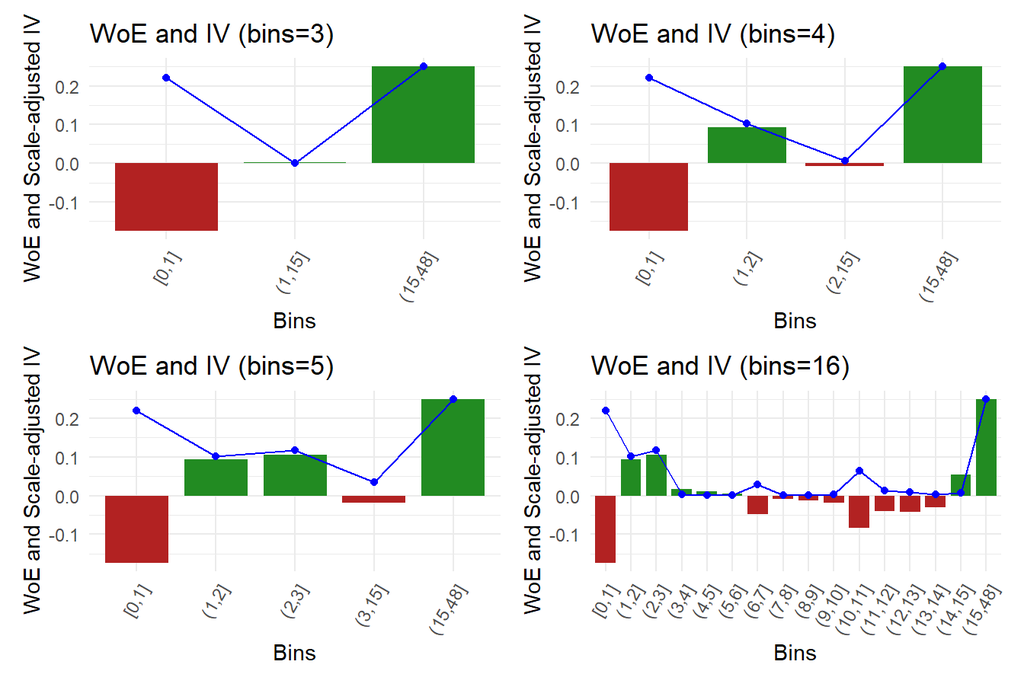

```r
plots_agec <- list()
for (i in c(3, 4, 5, 16)) {
    temp_bins_agec <- rebuild_bins(result_agec, i)
    woe_temp_agec <- woe_calc(data, x = "AGEC", y = "NCLAIMS", bins = temp_bins_agec)
    plots_agec[[i]] <- plot_woe_iv(woe_temp_agec, interactive = FALSE)
}
(plots_agec[[3]] | plots_agec[[4]]) / (plots_agec[[5]] | plots_agec[[16]])
```

The maximum binning shows us a clear separation of risk between:

- Brand new cars (AGEC close to 0) have the highest risk.
- Older cars (AGEC over 15 years) have a lower risk.

This is captured from 3 bins onward. Using 5 bins would allow us to capture the low-risk group for cars of 1 to 3 years old separately from the older low-risk cars. These cars are typically good new cars with conductors that have had the time to get used to them. We will thereforeuse 5 bins for the age of the car.

```r
data$AGEC_binned <- cut(
    data$AGEC,
    breaks = rebuild_bins(result_agec, 5)
    , include.lowest = TRUE, ordered_result = TRUE)
```

#### 2.2.2.6 Power Binning (POWER)

```r
baseline_power <- qbinning(data, x = "POWER", y = "NCLAIMS", max_bins = 30)
result_power <- iv_elbow(data, "POWER", "NCLAIMS", baseline_power)
plot_iv_elbow(result_power, interactive = TRUE)
```

[interactive chart not shown]

For the power of the car (`POWER`), we have stairs at 5, 7, and 12 bins. We’ll compare these three steps with the max level of bins (23).

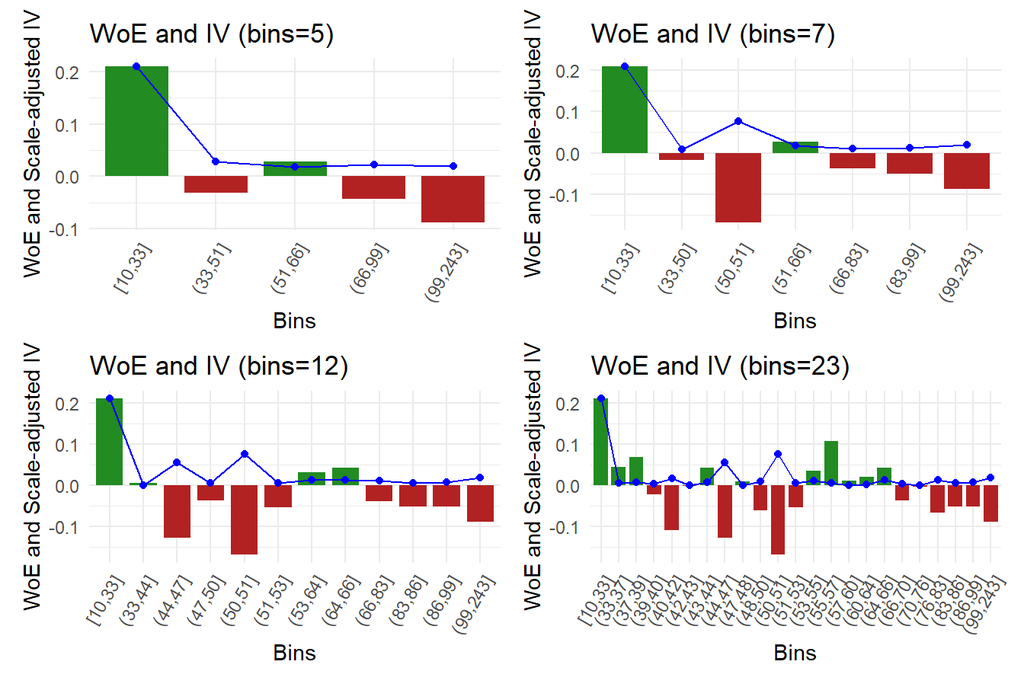

```r
plots_power <- list()
for (i in c(5, 7, 12, 23)) {
    temp_bins_power <- rebuild_bins(result_power, i)
    woe_temp_power <- woe_calc(data, x = "POWER", y = "NCLAIMS", bins = temp_bins_power)
    plots_power[[i]] <- plot_woe_iv(woe_temp_power, interactive = FALSE)
}
(plots_power[[5]] | plots_power[[7]]) / (plots_power[[12]] | plots_power[[23]])
```

The power constribution is harder to interpret. We have the low-power cars that are safer (lower claims), and high power that are more dangerous (higher claims). The middle range is not as clear. We notice two informative risk pockets (bins=12). A quick web search indicates these interpretations [^4]:

- Power between 44 and 47: this is the minimum legal and practical power for modern highway-legal cars. Below this range, cars are typically underpowered for regular driving conditions.
- Power between 50 and 51: this is widely considered the mechanical sweet spot to maintain highway speed withouf sacrificing fuel economy in urban driving. It is typically a marker of entry-level city cars.

Based on this interpretation, the power could be a proxy for the type of car and its urban usage. We will use 7 bins to account for the identification of entry-level city cars without overcomplicating the model with too many bins.

```r
data$POWER_binned <- cut(
    data$POWER,
    breaks = rebuild_bins(result_power, 7)
    , include.lowest = TRUE, ordered_result = TRUE)
```

We will end this Data Transformation section here now that we have bins for both categorical and numerical variables.

## 2.3 Data Exploration

### 2.3.1 Graphical Approach

Based on all created bins, we can visualize the claim frequency across different bins for each variable. This is what we already did in our analysis of the relation between the age of the driver and claim frequency. Remember that the MLE (Maximum Likelihood Estimator) for the claim frequency based on the hypothesis that the claims follow a Poisson distribution is the following:

$$NCLAIMS \sim \text{Poisson}(e\times
\lambda) \text{, where } e \text{ is the exposure and } \lambda \text{
is the claim frequency rate.}$$
$$\hat{\lambda} = \frac{\sum NCLAIMS}{\sum
e}$$
$$\hat{\lambda} \sim
\text{Normal}\left(\lambda, \frac{\lambda}{\sum_i
d_i}\right)$$

We find the variance as the inverse of the fisher information (itself equal to $-\ell''(\widehat{\lambda})$)
$$\text{Var}(\widehat{\lambda}) \approx
\mathcal{I}(\widehat{\lambda})^{-1} = \frac{\widehat{\lambda}}{\sum_i
d_i}.$$

Based on this mathematical understanding, we can build a main plot which shows exposures, claims, and claim frequencies with their confidence intervals (95 and 99%) across different bins for each variable.

```r
plot_claim_freq <- function(data, variable) {
    df_grouped <- data %>%
        mutate(bin = data[[variable]]) %>%
        group_by(bin) %>%
        summarise(
            sum_exp = sum(EXP),
            sum_claims = sum(NCLAIMS),
            lambda = sum_claims / sum_exp,
            sd_lambda = sqrt(lambda / sum_exp),
            lambda_95_lower = lambda - 1.96 * sd_lambda,
            lambda_95_upper = lambda + 1.96 * sd_lambda,
            lambda_99_lower = lambda - 2.58 * sd_lambda,
            lambda_99_upper = lambda + 2.58 * sd_lambda
        )
    df_grouped$sum_no_claims <- df_grouped$sum_exp - df_grouped$sum_claims
    df_counts <- bind_rows(
        mutate(df_grouped, bin = bin, value = sum_claims, metric = "Claims"),
        mutate(df_grouped, bin = bin, value = sum_no_claims, metric = "No Claims")
    )
    p_counts <- ggplot(df_counts, aes(x = bin, y = value, fill = metric)) +
        geom_bar(stat = "identity") + theme_minimal() +
        scale_fill_manual(values = c("Claims" = "firebrick", "No Claims" = "lightgray")) +
        labs(x = variable, y = "Count", fill = "Metric") +
        theme(axis.text.x = element_text(angle = 45, hjust = 1)) +
        ggtitle("Exposure Split")
    p_freq <- ggplot(df_grouped, aes(x = bin, group = 1)) +
        geom_ribbon(
            aes(ymin = lambda_99_lower, ymax = lambda_99_upper),
            fill = "gray", alpha = 0.3
        ) +
        geom_ribbon(
            aes(ymin = lambda_95_lower, ymax = lambda_95_upper),
            fill = "lightblue", alpha = 0.5
        ) +
        geom_line(aes(y = lambda), color = "black") +
        geom_point(aes(y = lambda), color = "black") +
        geom_hline(yintercept = mean_claim_frequency, color = "red", linetype = "dashed") +
        theme_minimal() +
        labs(
            x = variable,
            y = "Claim Frequency (Lambda)",
        ) +
        theme(axis.text.x = element_text(angle = 45, hjust = 1)) +
        ggtitle("Claim Frequency")
    p_all <- p_freq / p_counts
    p_all
}
```

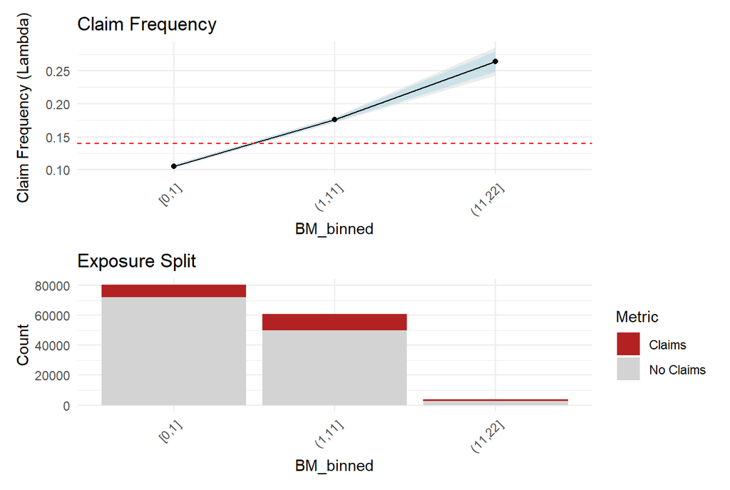

```r
plot_claim_freq(data, "BM_binned")
```

For this first example on the Bonus-Malus binned variable, we see a clear upward trend in the claim frequency as the Bonus-Malus level increases. This is expected as risky behaviour is translated in higher score on the BM scale. What is also interesting is that the claim frequency is a lot more precise for the 0 to 1 bin as the exposure is much higher compared to the higher BM levels. The confidence intervals also enable us to quickly test hypothesis that the claim frequency for a given bin is significantly different from the overall mean claim frequency (in red) or from other bins within the same variable[^5].

The same approach can be used for all variables:

#### 2.3.1.1 Categorical Variables

```
> COVERAGE
```

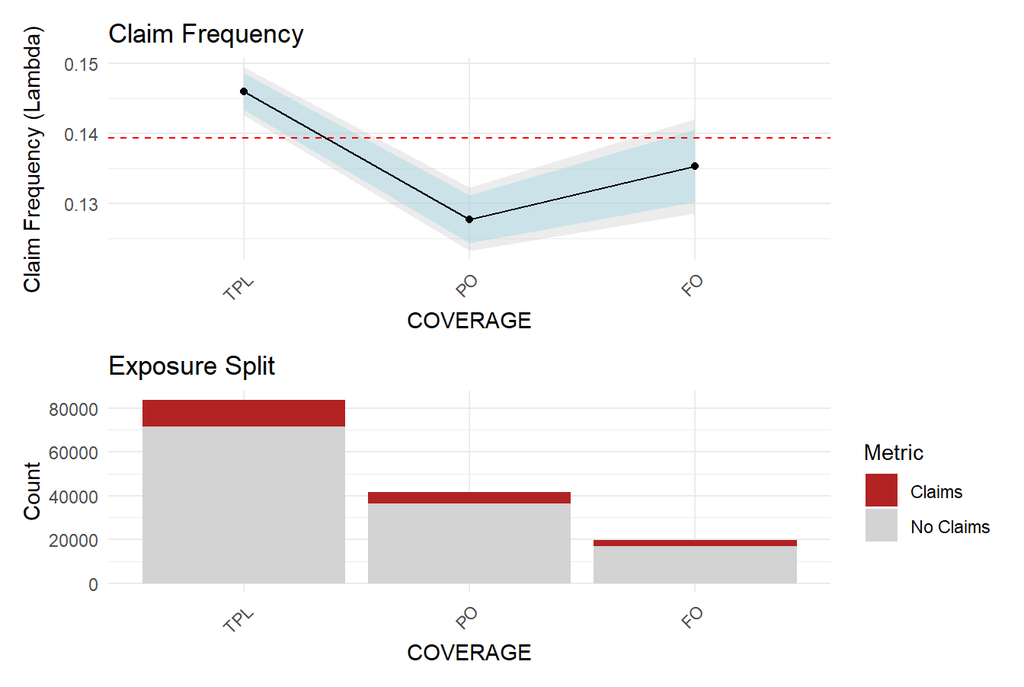

```
> FUEL
```

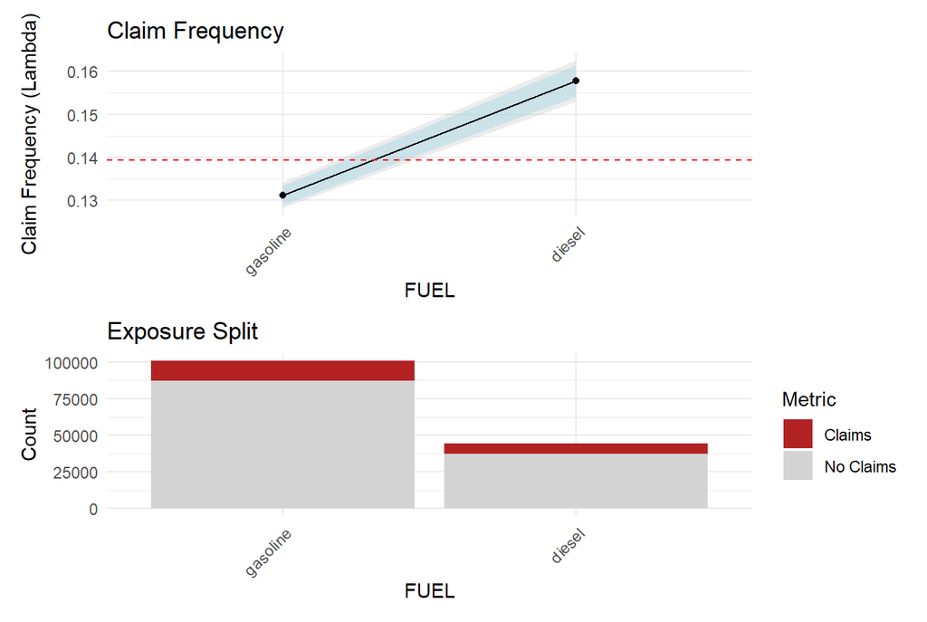

```
> USE
```

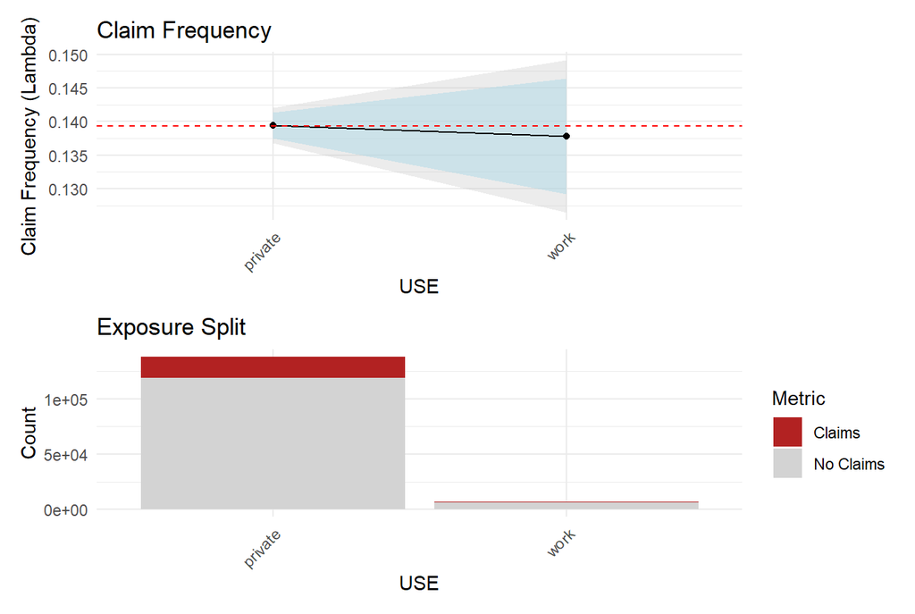

```
> FLEET
```

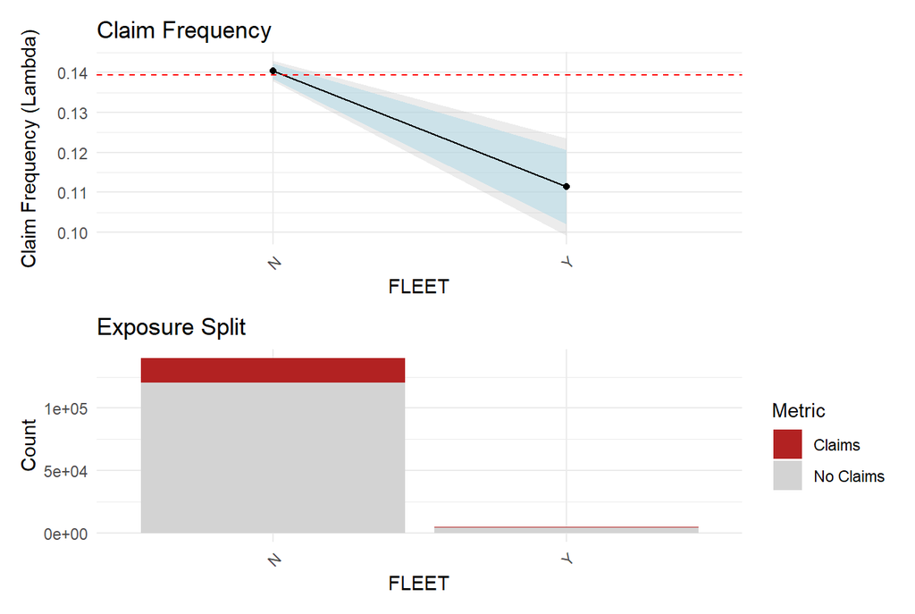

```
> SEX
```

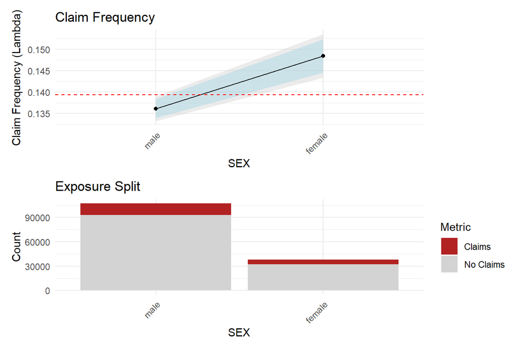

```r
for (cat_var in c("COVERAGE", "FUEL", "USE", "FLEET", "SEX")) {
    cat(paste0("> ", cat_var, "\n"))
    plot(plot_claim_freq(data, cat_var))
}
```

Based on the graphs, here are the preliminary conclusions for univariate analysis of categorical variables:

- `COVERAGE`

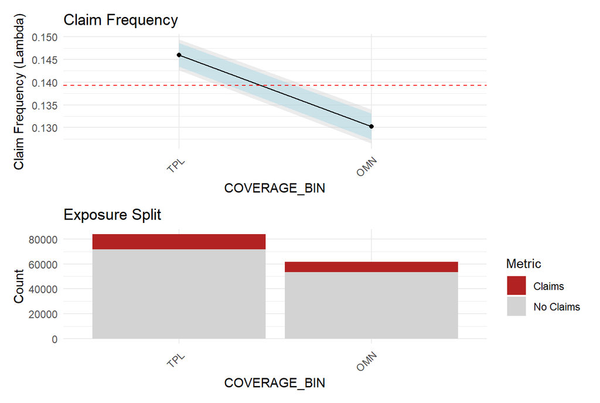

```r
data$COVERAGE_BIN <- ifelse(data$COVERAGE == "TPL", "TPL", "OMN")
data$COVERAGE_BIN <- as.factor(data$COVERAGE_BIN) %>% fct_infreq()
plot_claim_freq(data, "COVERAGE_BIN")
```

- `FUEL`

Diesel vehicles have significantly higher claim frequency compared to petrol vehicles. There is no obvious explanation for this statistical difference.

- `USE`

Private and professional use show no statistical differences from one another, nor from the mean. We will not include this variable in our models to avoid noise. Note that the proportion of policies related to work is very low, this has three consequences:

1. The private use looks very similar to the average as it represents the majority of the policies.
2. The work use is to variable to be statistically significant due to its low representation.
3. The variable is too unbalanced to provide reliable insights for modeling purposes.
- `FLEET`

Let’s compare the graph for fleet to the one of `USE`. Here again, we have a very unbalanced variable.

#### 2.3.1.2 Numerical Variables

Let us now have a look at the binned numerical variables other than the bonus-malus scale that we already interpreted.

```
> AGEPH_binned
```

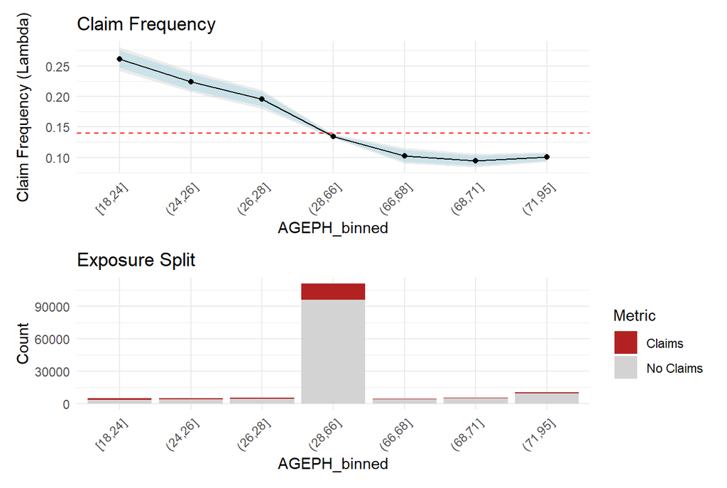

```
> AGEC_binned
```

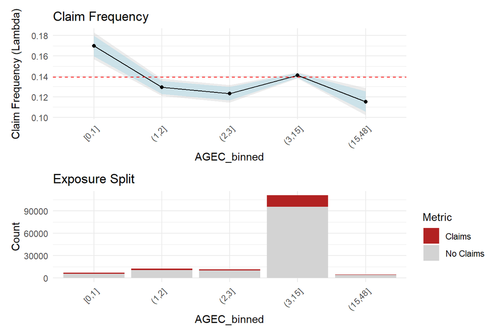

```
> POWER_binned
```

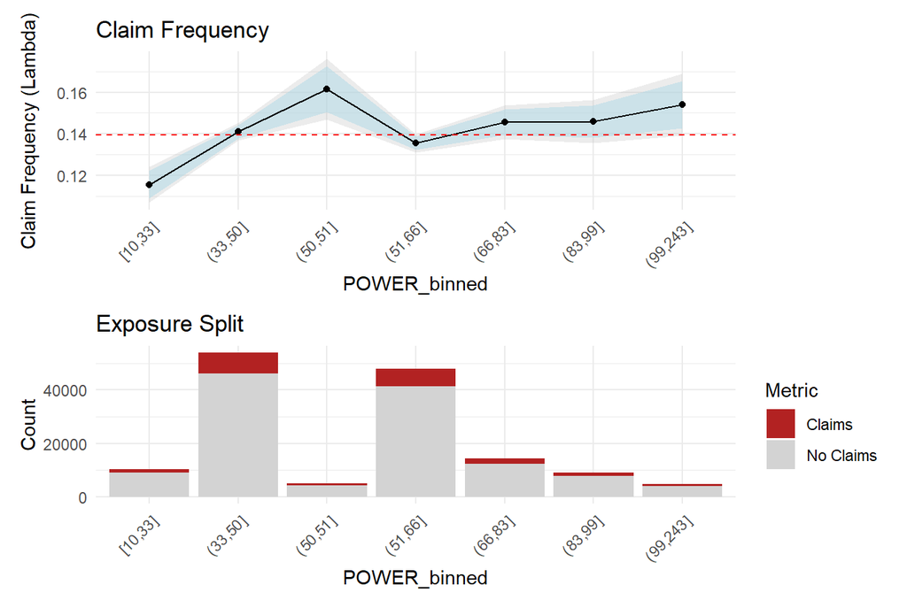

```r
for (cat_var in c("AGEPH_binned", "AGEC_binned", "POWER_binned")) {
    cat(paste0("> ", cat_var, "\n"))
    plot(plot_claim_freq(data, cat_var))
}
```

- `AGEPH_binned`

We see the risk diminution as the age of the policyholder increases as we identified with our binning algorithm. However, we see that the last three are not significantly different from one another in terms of claim frequency. We will come back to this in the statistical approach section and see with an anova test if the 7 bins are significantly better than a reduced number of bins.

- `AGEC_binned`

For the age of the car, we can confirm our previous observations that brand new cars (0-1 years old) have more claims. We can also confir the lower risk for cars between 1 and 3 years old and above 15 years. The remaining question is whether the bins 1 to 2 and 2 to 3 should be merged in a single bin. We will revisit this question in the statistical approach section to determine if merging these bins significantly affects the model performance.

- `POWER_binned`

Thanks to our binning algorithm, we correctly identified the low-risk for power lower than 33 kilowatts. We also correctly identified the very localised peak in risk for power 50 to 51 kilowatts. It is not clear whether the last 3 to 4 bins should be merged or kept separate, as the risk pattern is less pronounced in this range. We will also investigate this in the statistical approach section.

### 2.3.2 Statistical Approach

We already addressed the statistical significance by visually checking the confidence intervals around the claim frequencies. In this statistical data exploration, we will add two anova layers onto that visual inspection:

#### 2.3.2.1 Global Anova Test:

We will compare the deviance of the model with the variable as single predictor to the null model with only the offset term. This will allow us to test if the variable significantly improves the model fit:

$H_0: \var D = D_0 - D_1 = 0$ $H_1: \var D = D_0 - D_1 > 0$

Our $D_0$ represents the deviance of the null model with only the offset term: `glm(NCLAIMS ~ offset(log(EXP)))`. The $D_1$ represents the deviance of the model with the variable as a single predictor: `glm(NCLAIMS ~ offset(log(EXP)) + get(var))`.

```r
m0 <- glm(NCLAIMS ~ offset(log(EXP)), data = data, family = poisson(link = "log"))
sprintf("Because we use Poisson with its canonic link, note exp(Beta0) = %f is equal to the empiric claim frequency = %f", exp(coef(m0)[1]), sum(data$NCLAIMS)/sum(data$EXP))
```

```
[1] "Because we use Poisson with its canonic link, note exp(Beta0) = 0.139335 is equal to the empiric claim frequency = 0.139335"
```

Let’s now compare this null model to the models with each predictor variable individually.

```r
test_level <- 0.05
for (var in c("COVERAGE_BIN", "FUEL", "USE", "FLEET", "SEX", "BM_binned", "AGEPH_binned", "AGEC_binned", "POWER_binned")) {
    m1 <- glm(NCLAIMS ~ offset(log(EXP)) + get(var), data = data, family = poisson(link = "log"))
    test_result <- anova(m0, m1, test = "Chisq")
    cat(sprintf("Is variable %s significant? %s\n", var, ifelse(test_result$`Pr(>Chi)`[2] < test_level, "Yes", "No")))
}
```

```
Is variable COVERAGE_BIN significant? Yes
Is variable FUEL significant? Yes
Is variable USE significant? No
Is variable FLEET significant? Yes
Is variable SEX significant? Yes
Is variable BM_binned significant? Yes
Is variable AGEPH_binned significant? Yes
Is variable AGEC_binned significant? Yes
Is variable POWER_binned significant? Yes
```

With this first global anova test, we confirm our graphical approach, all variables should be kept except for `USE`.

#### 2.3.2.2 Merged bins

Let’s take the example of `COVERAGE` where we decided to merge the two omnium levels. Can we justify this statistically with the ANOVA test instead of simply with the confidence intervals?

```r
m0 <- glm(NCLAIMS ~ offset(log(EXP)) + COVERAGE_BIN, data = data, family = poisson(link = "log"))
m1 <- glm(NCLAIMS ~ offset(log(EXP)) + COVERAGE, data = data, family = poisson(link = "log"))
test_result <- anova(m0, m1, test = "Chisq")
pval <- test_result$`Pr(>Chi)`[2]
sprintf("Was it justified to merge the COVERAGE bins? %s", ifelse(pval < 0.05, "No", "Yes"))
```

```
[1] "Was it justified to merge the COVERAGE bins? No"
```

```r
sprintf("Are you 99%% sure that it was not justified? %s", ifelse(pval < 0.01, "Yes", "No"))
```

```
[1] "Are you 99% sure that it was not justified? No"
```

We can apply the same reasoning to clarify whether or not we should merge:

- The last 3 bins of `AGEPH_binned`

```
Merging the last 3 bins of AGEPH_binned was justified (p-value = 0.420586).
```

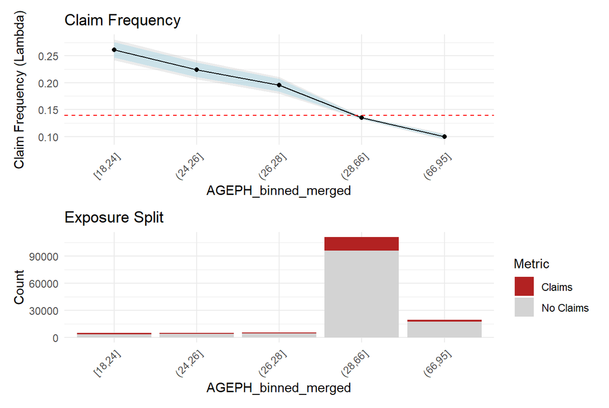

```r
data$AGEPH_binned_merged <- fct_collapse(
    data$AGEPH_binned,
    "(66,95]" = c("(66,68]", "(68,71]", "(71,95]")
)

m0 <- glm(NCLAIMS ~ offset(log(EXP)) + AGEPH_binned, data = data, family = poisson(link = "log"))
m1 <- glm(NCLAIMS ~ offset(log(EXP)) + AGEPH_binned_merged, data = data, family = poisson(link = "log"))
test_result <- anova(m0, m1, test = "Chisq")
pval <- test_result$`Pr(>Chi)`[2]

if(pval < 0.05) {
    cat(sprintf("Merging the last 3 bins of AGEPH_binned was not justified (p-value = %f).\n", pval))
} else {
    cat(sprintf("Merging the last 3 bins of AGEPH_binned was justified (p-value = %f).\n", pval))
    plot(plot_claim_freq(data, "AGEPH_binned_merged"))
}
```

- The bins 1-2 and 2-3 of `AGEC_binned`

```
Merging the second and third bins of AGEC_binned was justified (p-value = 0.184051).
```

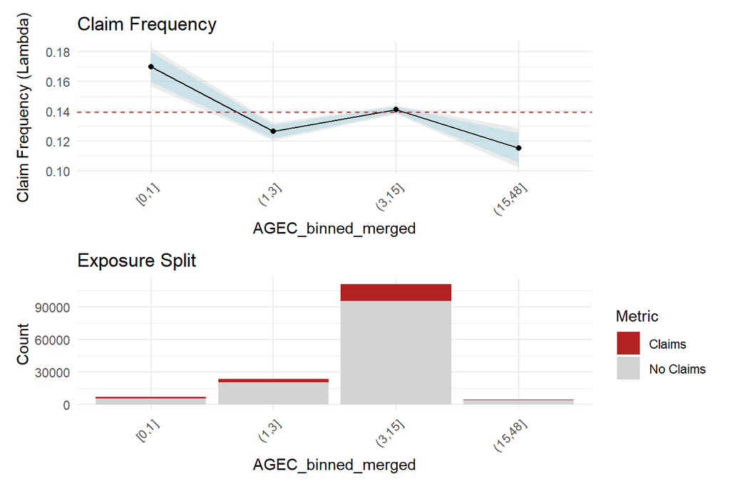

```r
data$AGEC_binned_merged <- fct_collapse(
    data$AGEC_binned,
    "(1,3]" = c("(1,2]", "(2,3]")
)

m0 <- glm(NCLAIMS ~ offset(log(EXP)) + AGEC_binned, data = data, family = poisson(link = "log"))
m1 <- glm(NCLAIMS ~ offset(log(EXP)) + AGEC_binned_merged, data = data, family = poisson(link = "log"))
test_result <- anova(m0, m1, test = "Chisq")
pval <- test_result$`Pr(>Chi)`[2]

if(pval < 0.05) {
    cat(sprintf("Merging the second and third bins of AGEC_binned was not justified (p-value = %f).\n", pval))
} else {
    cat(sprintf("Merging the second and third bins of AGEC_binned was justified (p-value = %f).\n", pval))
    plot(plot_claim_freq(data, "AGEC_binned_merged"))
}
```

- The last 3 or last four bins of `POWER_binned`

```
Merging the last 4 bins of POWER_binned was not justified (p-value = 0.000291).
But merging the last 3 bins of POWER_binned was justified (p-value = 0.399707).
```

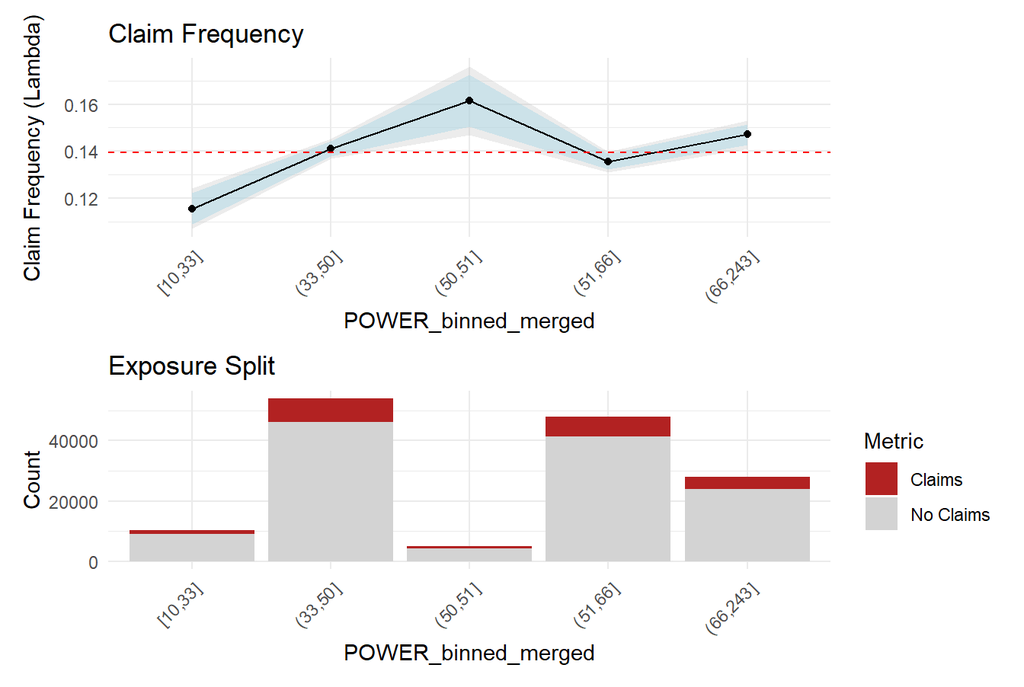

```r
data$POWER_binned_merged <- fct_collapse(
    data$POWER_binned,
    "(51,243]" = c("(51,66]", "(66,83]", "(83,99]", "(99,243]")
)

m0 <- glm(NCLAIMS ~ offset(log(EXP)) + POWER_binned, data = data, family = poisson(link = "log"))
m1 <- glm(NCLAIMS ~ offset(log(EXP)) + POWER_binned_merged, data = data, family = poisson(link = "log"))
test_result <- anova(m0, m1, test = "Chisq")
pval <- test_result$`Pr(>Chi)`[2]

if(pval < 0.05) {
    cat(sprintf("Merging the last 4 bins of POWER_binned was not justified (p-value = %f).\n", pval))
    data$POWER_binned_merged <- fct_collapse(
        data$POWER_binned,
        "(66,243]" = c("(66,83]", "(83,99]", "(99,243]")
    )

    m0 <- glm(NCLAIMS ~ offset(log(EXP)) + POWER_binned, data = data, family = poisson(link = "log"))
    m1 <- glm(NCLAIMS ~ offset(log(EXP)) + POWER_binned_merged, data = data, family = poisson(link = "log"))
    test_result <- anova(m0, m1, test = "Chisq")
    pval <- test_result$`Pr(>Chi)`[2]

    if(pval < 0.05) {
        cat(sprintf("And merging the last 3 bins of POWER_binned was not justified either (p-value = %f).\n", pval))
    } else {
        cat(sprintf("But merging the last 3 bins of POWER_binned was justified (p-value = %f).\n", pval))
        plot(plot_claim_freq(data, "POWER_binned_merged"))
    }
} else {
    cat(sprintf("Merging the last 4 bins of POWER_binned was justified (p-value = %f).\n", pval))
    plot(plot_claim_freq(data, "POWER_binned_merged"))
}
```

## 2.4 Feature Engineering

### 2.4.1 Geospatial Features

### 2.4.2 Polynomial Features

### 2.4.3 Interaction Features

# 3 Modelling

## 3.1 Validation Framework

### 3.1.1 Performance Metrics

### 3.1.2 Statistical Tests

### 3.1.3 Cross-Validation

## 3.2 Frequency Modelling

### 3.2.1 Naive and Full Models

### 3.2.2 GLM Models

### 3.2.3 GAM Models

### 3.2.4 Hurdle Models

### 3.2.5 Final Frequency Model

## 3.3 Severity Modelling

### 3.3.1 GLM Models

### 3.3.2 Final Severity Model

# 4 Global Overview

## 4.1 Importance of Features

## 4.2 Final Premium Structure

# 5 Bonus Analysis

## 5.1 Alternative Tweedie Approach

## 5.2 Geospatial Insights

# 6 Conclusion

[^1]: For policies with no claims, `AMOUNT` is zero; `AVG` is undefined.
[^2]: In frequency modelling, the exposure is typically included as an offset in the model to adjust for the varying lengths of policy coverage. This ensures that the estimated claim frequency accurately reflects the risk per unit of exposure rather than per policy.
[^3]: The confidence intervals are based on the MLE estimator for the claim frequency under the assumption of a Poisson distribution for the number of claims.
[^4]: The interpretations are the result of google IA’s search and should be taken with caution. A true market research and assessment of the hidden factors is outside the scope of this assignment.
[^5]: If the value is outside of the blue range, we can reject the hypothesis that the claim frequency for that bin is equal to the value with 95% certainty. For the grey interval, we can reject the hypothesis with 99% certainty.